# RNA-seq analysis in R - Instructor Materials

Gene Set Testing for RNA-seq

Stephane Ballereau, Mark Dunning, Abbi Edwards, Oscar Rueda, Ashley Sawle

Last modified: 26 Oct 2022

# GSEA analysis

- rank all genes in the `data set`
- identifying the rank positions of all members of the `gene set`
- calculating an enrichment score (ES)
- permute to generate a statistic

## `fgsea`

The `fgsea` package [@Sergushichev2016] implements the same algorithm in R [vignette](http://www.bioconductor.org/packages/release/bioc/vignettes/fgsea/inst/doc/fgsea-tutorial.html) “fast preranked gene set enrichment analysis (GSEA)”.

```r
load(".data/Robjects/exampleProject/Annotated_Results_LvV.RData")
```

## Create ranks

```r
head(ranks)
```

```
    497097      19888      20671      27395      18777      21399
 0.5851914 -1.0498457 -0.5893634  0.4313540  0.6478714 -0.1110589
```

Plot the ranked fold changes.

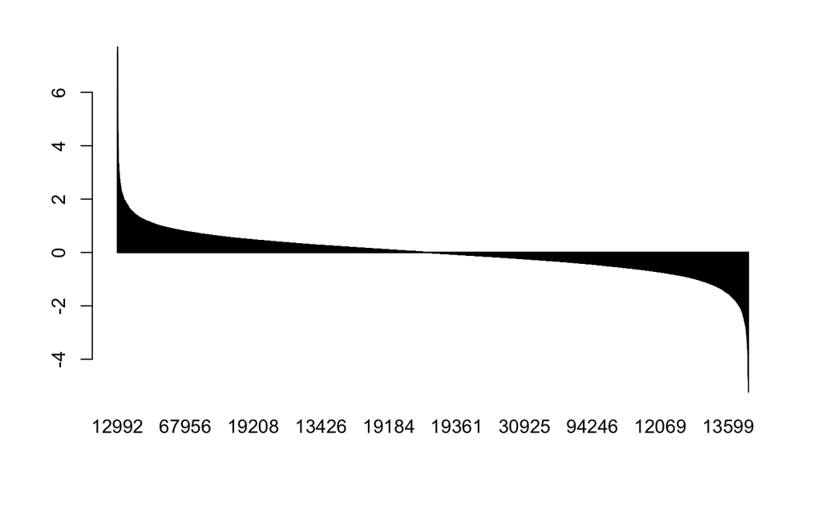

## Conduct analysis

```r
fgseaRes <- fgsea(pathwaysH, ranks, minSize=15, maxSize = 500, nperm=1000)
```

- Lets look at the top 10 results.

| pathway | pval | padj | ES | NES | nMoreExtreme | size | leadingEdge |
| --- | --- | --- | --- | --- | --- | --- | --- |
| HALLMARK_OXIDATIVE_PHOSPHORYLATION | 0.002915452 | 0.009718173 | 0.5164058 | 2.348526 | 0 | 197 |  |
| HALLMARK_CHOLESTEROL_HOMEOSTASIS | 0.002450980 | 0.009718173 | 0.5981073 | 2.325014 | 0 | 72 |  |
| HALLMARK_TGF_BETA_SIGNALING | 0.001730104 | 0.009718173 | -0.5947161 | -2.085495 | 0 | 53 |  |
| HALLMARK_ADIPOGENESIS | 0.002898551 | 0.009718173 | 0.4495508 | 2.052532 | 0 | 199 |  |
| HALLMARK_FATTY_ACID_METABOLISM | 0.002717391 | 0.009718173 | 0.4462902 | 1.976872 | 0 | 154 |  |
| HALLMARK_NOTCH_SIGNALING | 0.001801802 | 0.009718173 | -0.6049741 | -1.892870 | 0 | 31 |  |
| HALLMARK_MTORC1_SIGNALING | 0.002915452 | 0.009718173 | 0.4072729 | 1.858149 | 0 | 201 |  |
| HALLMARK_KRAS_SIGNALING_UP | 0.001540832 | 0.009718173 | -0.4237794 | -1.818634 | 0 | 190 |  |
| HALLMARK_ESTROGEN_RESPONSE_EARLY | 0.001545595 | 0.009718173 | -0.4205405 | -1.806194 | 0 | 193 |  |
| HALLMARK_MYC_TARGETS_V2 | 0.001683502 | 0.009718173 | -0.4967001 | -1.777415 | 0 | 58 |  |

[output cut: 5 more lines]

## Enrichment score plot

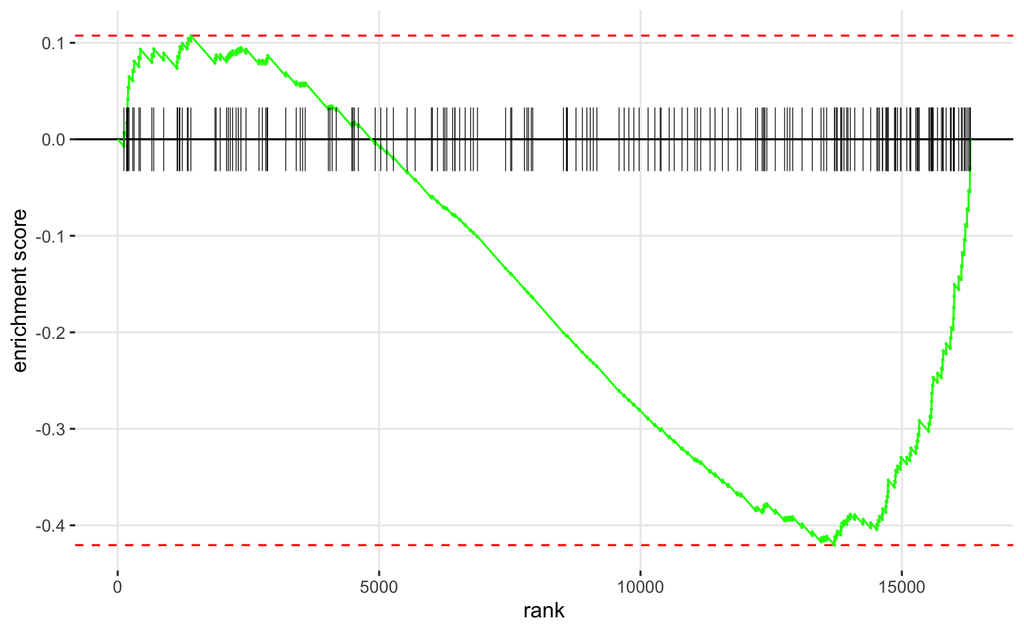

## GSEA table plot

The function `plotGseaTable` allows us to plot a summary figue showing the results for multiple pathways.

```r
plotGseaTable(pathwaysH[topPathways],
              rankData,
              fgseaRes,
              gseaParam = 0.5,
              render = FALSE)
```

[output not shown]

[output cut: 100 more lines]

## Challenge 1

> Another common way to rank the genes is to order by pvalue, but also, sorting so that upregulated genes are at start and downregulated at the other - you can do this combining the sign of the fold change and the pvalue.  
> 1. Rank the genes by statisical significance - you will need to create a new ranking value using `-log10({p value}) * sign({Fold Change})`  
> 2. Load the “C2” pathways from the the `data/mouse_c2_v5.RData` file  
> 3. Run `fgsea` using the new ranked genes and the C2 pathways  
> 4. Run `fgsea` using the new ranked genes and the H pathways. How do these results differ from the ones we got when ranking by the fold change alone?

# GO enrichment analysis

## `goseq`

- GOseq accounts for the gene length bias

```r
library(goseq)
supportedOrganisms() %>% filter(str_detect(Genome, "mm"))
```

## Create a list of differentially expressed genes

```r
isSigGene <- shrinkLvV$FDR < 0.01 & !is.na(shrinkLvV$FDR)
genes <- as.integer(isSigGene)
names(genes) <- shrinkLvV$GeneID
```

## Fit the Probability Weighting Function (PWF)

```r
pwf <- nullp(genes, "mm10", "ensGene", bias.data = shrinkLvV$medianTxLength)
```

## Conduct GO enrichment analysis

```r
goResults <- goseq(pwf, "mm10","ensGene", test.cats=c("GO:BP"))
```

## Plot the top 10

```r
goResults %>%
    top_n(10, wt=-over_represented_pvalue) %>%
    mutate(hitsPerc=numDEInCat*100/numInCat) %>%
    ggplot(aes(x=hitsPerc,
               y=term,
               colour=over_represented_pvalue,
               size=numDEInCat)) +
        geom_point() +
        expand_limits(x=0) +
        labs(x="Hits (%)", y="GO term", colour="p value", size="Count")
```

[output not shown]

## Get the GO information for the GO accessions

```r
library(GO.db)
GOTERM[[goResults$category[1]]]
```

## Challenge 2

> 1. Create a list of genes that are statistically significant at FDR < 0.01 and are up-regulated by at least 4x (logFC>2) in lactating mice
> 2. Run a `goseq` analysis on this gene list
> 3. Plot the results
> 4. How is this result different to the previous GO analysis?

```r
isSigGeneUp <- shrinkLvV$FDR < 0.01 &
    !is.na(shrinkLvV$FDR) &
    shrinkLvV$logFC > 2

genesUp <- as.integer(isSigGeneUp)
names(genesUp) <- shrinkLvV$GeneID

pwf <- nullp(genesUp, "mm10", "ensGene", bias.data = shrinkLvV$medianTxLength)

goResultsUp <- goseq(pwf, "mm10","ensGene", test.cats=c("GO:BP"))

goResultsUp %>%
    top_n(10, wt=-over_represented_pvalue) %>%
    mutate(hitsPerc=numDEInCat*100/numInCat) %>%
    ggplot(aes(x=hitsPerc,
               y=term,
               colour=over_represented_pvalue,
               size=numDEInCat)) +
        geom_point() +
        expand_limits(x=0) +
        labs(x="Hits (%)", y="GO term", colour="p value", size="Count")
```

# KEGG pathway enrichment analysis

## `clusterProfiler`

- `clusterprofiler` direct online access of the current KEGG database

```r
library(clusterProfiler)
search_kegg_organism('mmu', by='kegg_code')
```

## KEGG enrichment analysis

```r
sigGenes <- shrinkLvV$Entrez[ shrinkLvV$FDR < 0.01 &
                              !is.na(shrinkLvV$FDR) &
                              abs(shrinkLvV$logFC) > 1 ]
sigGenes <- na.exclude(sigGenes)
kk <- enrichKEGG(gene = sigGenes, organism = 'mmu')
head(kk, n=10)
```

## Visualise a pathway

### In a browser

```r
browseKEGG(kk, 'mmu03320')
```

### As a file

```r
library(pathview)

logFC <- annotLvV$logFC
names(logFC) <- annotLvV$Entrez
pathview(gene.data = logFC,
         pathway.id = "mmu03320",
         species = "mmu",
         limit = list(gene=5, cpd=1))
```

## Challenge 3

> 1. Use `pathview` to export a figure for “mmu04060”, but this time only use genes that are statistically significant at FDR < 0.01

```r
sigGenes <- shrinkLvV$FDR < 0.01 & !is.na(shrinkLvV$FDR)

logFC <- annotLvV$logFC[sigGenes]
names(logFC) <- annotLvV$Entrez[sigGenes]

pathview(gene.data = logFC,
         pathway.id = "mmu04060",
         species = "mmu",
         limit = list(gene=5, cpd=1))
```